# Module 8 Mini Assignment (Individual)

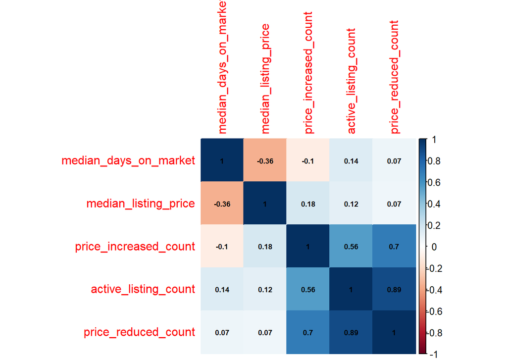

```r
corrplot(cdf5
         , method = 'color' #pie and ellipse
         , order = 'hclust' #orders the variables so that ones that behave similarly are placed next to each other
         , addCoef.col = 'black'
         , number.cex = .6  #lower values decrease the size of the numbers in the cells
         )
```

13. Run your model/ algorithm.

```r
#Linear Regression No.1
lm1 <- lm(median_listing_price ~ active_listing_count + pending_listing_count + median_listing_price + median_listing_price_per_square_foot + total_listing_count, data = df5)
summary(lm1)
```

```
##
## Call:
## lm(formula = median_listing_price ~ active_listing_count + pending_listing_count +
##     median_listing_price + median_listing_price_per_square_foot +
##     total_listing_count, data = df5)
##
## Residuals:
##     Min      1Q  Median      3Q     Max
## -444.05  -30.30   -4.16   26.98  486.07
##
## Coefficients:
##                                        Estimate Std. Error t value Pr(>|t|)
## (Intercept)                           76.867608   1.561481  49.227   <2e-16 ***
## active_listing_count                 -33.920736  15.553741  -2.181   0.0292 *
## pending_listing_count                 -0.033303   0.015565  -2.140   0.0324 *
## median_listing_price_per_square_foot   1.500096   0.007067 212.263   <2e-16 ***
## total_listing_count                    0.033890   0.015554   2.179   0.0294 *
## ---
## Signif. codes:  0 '***' 0.001 '**' 0.01 '*' 0.05 '.' 0.1 ' ' 1
##
## Residual standard error: 59.65 on 5862 degrees of freedom
## Multiple R-squared:  0.8887, Adjusted R-squared:  0.8886
## F-statistic: 1.17e+04 on 4 and 5862 DF,  p-value: < 2.2e-16
```

```r
#Linear Regression No.2
lm2 <- lm(median_listing_price ~ active_listing_count + median_days_on_market + pending_ratio + pending_listing_count + median_listing_price + median_listing_price_per_square_foot + median_square_feet + total_listing_count, data = df5)
summary(lm2)
```

```
##
## Call:
## lm(formula = median_listing_price ~ active_listing_count + median_days_on_market +
##     pending_ratio + pending_listing_count + median_listing_price +
##     median_listing_price_per_square_foot + median_square_feet +
##     total_listing_count, data = df5)
##
## Residuals:
##     Min      1Q  Median      3Q     Max
## -329.53  -12.75    1.26   13.76  378.13
##
## Coefficients:
##                                        Estimate Std. Error t value Pr(>|t|)
## (Intercept)                          -2.637e+02  4.213e+00 -62.584  < 2e-16 ***
## active_listing_count                 -4.180e+00  8.883e+00  -0.470    0.638
## median_days_on_market                -2.752e-01  2.780e-02  -9.901  < 2e-16 ***
## pending_ratio                         5.344e+00  7.114e-01   7.512 6.72e-14 ***
## pending_listing_count                -5.784e-03  8.888e-03  -0.651    0.515
## median_listing_price_per_square_foot  1.614e+00  4.469e-03 361.120  < 2e-16 ***
## median_square_feet                    1.672e-01  1.571e-03 106.476  < 2e-16 ***
## total_listing_count                   4.701e-03  8.883e-03   0.529    0.597
## ---
## Signif. codes:  0 '***' 0.001 '**' 0.01 '*' 0.05 '.' 0.1 ' ' 1
##
## Residual standard error: 34.03 on 5859 degrees of freedom
## Multiple R-squared:  0.9638, Adjusted R-squared:  0.9637
## F-statistic: 2.227e+04 on 7 and 5859 DF,  p-value: < 2.2e-16
```

```r
#Linear Regression No.3
lm3 <- lm(median_listing_price ~ median_days_on_market + pending_ratio + median_listing_price + median_listing_price_per_square_foot + median_square_feet, data = df5)
summary(lm3)
```

```
##
## Call:
## lm(formula = median_listing_price ~ median_days_on_market + pending_ratio +
##     median_listing_price + median_listing_price_per_square_foot +
##     median_square_feet, data = df5)
##
## Residuals:
##     Min      1Q  Median      3Q     Max
## -329.71  -12.53    1.31   13.61  378.33
##
## Coefficients:
##                                        Estimate Std. Error t value Pr(>|t|)
## (Intercept)                          -2.629e+02  4.227e+00 -62.194  < 2e-16 ***
## median_days_on_market                -2.557e-01  2.767e-02  -9.241  < 2e-16 ***
## pending_ratio                         3.034e+00  6.378e-01   4.757 2.01e-06 ***
## median_listing_price_per_square_foot  1.614e+00  4.406e-03 366.321  < 2e-16 ***
## median_square_feet                    1.670e-01  1.573e-03 106.178  < 2e-16 ***
## ---
## Signif. codes:  0 '***' 0.001 '**' 0.01 '*' 0.05 '.' 0.1 ' ' 1
##
## Residual standard error: 34.18 on 5862 degrees of freedom
## Multiple R-squared:  0.9635, Adjusted R-squared:  0.9634
## F-statistic: 3.864e+04 on 4 and 5862 DF,  p-value: < 2.2e-16
```

14. Report model performance. For explanatory models report p-value for the independent variable(s) of interest and for predictive models report a confusion matrix and any other metrics such as sensitivity, specificity, precision, recall, R-squared, etc. as desired based on the business problem. For a clustering algorithm, discuss the clusters that are created.
15. Write a summary that includes the following: business problem (point 5 above), description and justification of the machine learning algorithm chosen, comments on the model performance, and insights from the model results. The suggested length is between 250 and 500 words.

**Business Problem:**  
**Realtor.com provides many data related to residential housing market. This data captures top 100 metropolitan cities in the U.S. Whether it’s a single family looking to buy a house or a large real estate private equity deciding which metric to focus on for the next investment, it’s crucial to see which columns of the dataset are statistically significant to the housing prices because main stream media may present with miss leading indicators based on superficial beliefs. This solves the business/personal problem of buying a house for business/personal investing for housing without bias.**

**Model Justification**  
**I tried all four methods of the algorithms. The most challenging part was preparing the data to fit into the algorithms other than linear regression. I was able to implement the data with little to no prep work. Since all the data was prepared and given to the students, I had little to no guidance on how to prepare the data. Closest to the implementation phase was the logistic algorithm. However, it was still challenging to produce any substantial outcome compared to linear regression as shown above which I felt was the outside the scope of this class. I’m hoping to explore more in details as my personal project to validate or adjust my linear regression model with the same dataset.**

**Model Description & Performance:**  
**The model performed very well with this particular dataset with linear regression. I was able to find which metrics are statistically significant and which are not to the median listing price (housing prices) which many would be interested in. active_listing_count, pending_listing_count, and total_listing_count had very high p-value 0.638, 0.515, and 0.597 respectively. Meaning they were not statistically significant. Looking at the report of the model performance and the output, it gave me an insight that maybe we shouldn’t focus so much on the total listing or inventory of the market than what the mainstream media or Realtors are emphasizing it to be as one of the main indicators of the residential real estate market condition. Instead, we should focus on median_days_on_market, pending_ratio, median_listing_price_per_square_foot and median_square_feet because they all had very low p-value with three stars. The adjusted R-squared was very high as well with 0.9634. However, we may want to adjust the data to compare with other algorithms such as logistic regression to validate the output of this model.**